# The Mockup - gt Tables Tutorial

Tom Mock published a tutorial in *The Mockup* blog demonstrating the *gt* package. Tom’s blog was inspired by the work of J. A. Schwabish (2020). Tom’s tutorial repreduced here, contains minor changes to Tom Mock’s code. Some of Tom’s code has been depricated and I introduce other minor changes to Tom’s code, including accessing the TidyTuesday data source as a csv file and importing the dataset directlyi with the {*readr*} package. Otherwise, the material is close to a *verbatim* reproduction of Tom’s tutorial.

Complementing *The Mockup* tutorial on creating tables in R with the *gt* package, David Keyes of *RfortheRestofUs* created a YouTube tutorial [Making high-quality tables in R with the gt package: a conversation with Tom Mock.](https://www.youtube.com/watch?v=dxDeotwylr8). David’s tutorial illustrates how to access the TidyTuesday datasets. Tom Mock’s tutorial references the TidyTuesday dataset but does not explain how to retrieve the data. Keyes’ tutorial discusses Mock’s code and the table guidelines introduced by J.A. Schwabish.

**Package versions**

- R 4.2.2
- RStudio 2022.12.0+353 “Elsbeth Geranium” Release (2022-12-03) for Windows
- {*gt*} version 0.6.0.
  - Current version of {*gt*} is 0.7.0. Using 0.7.0, I had failure in creating parameterized repoorts, so I uninstalled 0.7.0 and reinstalled 0.6.0.

[The Mockup 10+ Guidelines for Better Tables in R](https://themockup.blog/posts/2020-09-04-10-table-rules-in-r/)

[R for the rest of Us YouTube Tutorial {gt} package](https://www.youtube.com/watch?v=dxDeotwylr8)

Schwabish, J. A. (2020). Ten Guidelines for Better Tables. Journal of Benefit-Cost Analysis, 11(2), 151–178. https://doi.org/10.1017/bca.2020.11

[figure not shown]

[^1] Figure 1. Table Parts (Schwabish, 2020)

[click here for the Rstudio *gt* site](https://gt.rstudio.com/)

## Rule 1: Offset heads from body

- Tidy format is not the best for presentation
- Make the table wider
- Make column titles clear
  - Offset column titles with boldface type or lines
- Using *filter(var %in% c(“var1”, “var2”))*
- cols__hide()

| Country | crop | 2014 | 2015 | 2016 |
| --- | --- | --- | --- | --- |
| China | maize | 5.8091 | 5.8929 | 5.9667 |
| China | potatoes | 17.1416 | 17.2684 | 17.6866 |
| India | maize | 2.6107 | 2.5972 | 2.6162 |
| India | potatoes | 22.9224 | 23.1257 | 20.5087 |
| Indonesia | maize | 4.9540 | 5.1784 | 5.3052 |
| Indonesia | potatoes | 17.6668 | 18.2027 | 18.2549 |
| Mexico | maize | 3.2964 | 3.4782 | 3.7180 |
| Mexico | potatoes | 27.3384 | 27.1435 | 27.9260 |
| United States | maize | 10.7326 | 10.5723 | 11.7433 |
| United States | potatoes | 47.1507 | 46.9000 | 48.6408 |

### Pivot Wider

| Country | 2013 | 2014 | 2015 | 2016 |
| --- | --- | --- | --- | --- |
| China | 17.09 | 17.14 | 17.27 | 17.69 |
| India | 22.76 | 22.92 | 23.13 | 20.51 |
| Indonesia | 16.02 | 17.67 | 18.20 | 18.25 |
| Mexico | 26.78 | 27.34 | 27.14 | 27.93 |
| Pakistan | 21.81 | 18.15 | 23.44 | 22.43 |
| United States | 46.36 | 47.15 | 46.90 | 48.64 |

**Table**: @thomas_mock | **Data**: OurWorldInData.org **Inspiration**: @jschwabish

### Rule 2: Use subtle Dividers rathen than heavy gridlines

- tab_style()
- see stackoverflow to conditionally fill tab_style[^2]

| Country | code | 2007 | 2008 | 2009 | 2010 | 2011 | avg_07_11 | 2012 | 2013 | 2014 | 2015 | 2016 | avg_12_16 |
| --- | --- | --- | --- | --- | --- | --- | --- | --- | --- | --- | --- | --- | --- |
| China | CHN | 14.6283 | 15.1820 | 14.4171 | 15.6686 | 16.2826 | 15.1283 | 16.7712 | 17.0910 | 17.1416 | 17.2684 | 17.6866 | 16.7712 |
| India | IND | 16.4101 | 19.2973 | 18.8103 | 19.9299 | 22.7240 | 19.4101 | 21.7530 | 22.7606 | 22.9224 | 23.1257 | 20.5087 | 21.2530 |
| Indonesia | IDN | 16.0919 | 16.6719 | 16.5123 | 15.9445 | 15.9562 | 16.0919 | 16.5820 | 16.0184 | 17.6668 | 18.2027 | 18.2549 | 17.0820 |
| Mexico | MEX | 27.0565 | 27.7258 | 27.7374 | 27.7578 | 26.2734 | 27.0565 | 26.8098 | 26.7752 | 27.3384 | 27.1435 | 27.9260 | 27.3098 |
| Pakistan | PAK | 19.3516 | 16.4550 | 20.2848 | 22.6823 | 21.9196 | 20.3516 | 18.3405 | 21.8059 | 18.1506 | 23.4439 | 22.4346 | 20.3405 |
| United States | USA | 44.4336 | 44.4373 | 46.4446 | 44.9438 | 44.6923 | 44.4336 | 45.7762 | 46.3577 | 47.1507 | 46.9000 | 48.6408 | 46.7762 |

- Create gt object, then loop over the sequence of rows in a for-loop to color the argument in cell_fill.
- getting an error “The following row indices do not exist in the data: 7

### 3. Addendums to alignment

- Center Align: When aligning text of equal length (long or very short), center alignment of text can be fine or even preferable. For example, very *short text with a long header* can be better suited to center-align.
- Equal length text can be centered without negatively affecting the ability to quickly read.

While the table below could be improved in other ways and has quite a bit of repetition, note that the Top Crop column has too much white space on the right side due to defaulting to left-alignment. This makes it “stick” too much to the adjacent column.

| Year | Crop | Top Crop | Yield |
| --- | --- | --- | --- |
| 2015 | Wheat | N | 2.9299 |
| 2015 | Maize | Y | 10.5723 |
| 2015 | Beans | N | 1.9729 |
| 2016 | Wheat | N | 3.5408 |
| 2016 | Maize | Y | 11.7433 |
| 2016 | Beans | N | 2.0648 |
| 2017 | Wheat | N | 3.1175 |
| 2017 | Maize | Y | 11.8754 |
| 2017 | Beans | N | 1.9927 |
| 2018 | Wheat | N | 3.1999 |
| 2018 | Maize | Y | 11.8639 |
| 2018 | Beans | N | 2.0843 |

Moving the Top Crop column to center-alignment makes it easier to visually parse the column, and note that centering the Crop Column has no negative effect on the alignment or ability to read as each cell value has equal length (as long as the font-choice is one that doesn’t have major differenceds in charater width). The left-alignment rule for text is a good default, but is more effective with variable width text especially with large variation (ie length = 10 interspersed with length = 5).

| Year | Crop | Top Crop | Yield |
| --- | --- | --- | --- |
| 2015 | Wheat | N | 2.9299 |
| 2015 | Maize | Y | 10.5723 |
| 2015 | Beans | N | 1.9729 |
| 2016 | Wheat | N | 3.5408 |
| 2016 | Maize | Y | 11.7433 |
| 2016 | Beans | N | 2.0648 |
| 2017 | Wheat | N | 3.1175 |
| 2017 | Maize | Y | 11.8754 |
| 2017 | Beans | N | 1.9927 |
| 2018 | Wheat | N | 3.1999 |
| 2018 | Maize | Y | 11.8639 |
| 2018 | Beans | N | 2.0843 |

### Pivot wider to improve table

| Crop | Top Crop | 2015 | 2016 | 2017 | 2018 |
| --- | --- | --- | --- | --- | --- |
| Wheat | N | 2.9299 | 3.5408 | 3.1175 | 3.1999 |
| Maize | Y | 10.5723 | 11.7433 | 11.8754 | 11.8639 |
| Beans | N | 1.9729 | 2.0648 | 1.9927 | 2.0843 |

### Rule 4: Left-align Text and Heads

**For labels/strings** it is typically more appropriate to left-align. This allows your eye to follow both short and long text vertically to scan a table, along with a clear border.

- cols_label( left = md(“Left-aligned and  
  easiest to read”) )

| Right aligned and hard to read | Centered and even harder to read | Left-aligned and easiest to read |
| --- | --- | --- |
| British Virgin Islands | British Virgin Islands | British Virgin Islands |
| Cayman Islands | Cayman Islands | Cayman Islands |
| Democratic Republic of Congo | Democratic Republic of Congo | Democratic Republic of Congo |
| Luxembourg | Luxembourg | Luxembourg |
| United States | United States | United States |
| Germany | Germany | Germany |
| New Zealand | New Zealand | New Zealand |
| Costa Rica | Costa Rica | Costa Rica |
| Peru | Peru | Peru |

**Table**: @thomas_mock | **Data**: OurWorldInData.org **Inspiration**: @jschwabish

### Rule 5: Select the Appropriate Level of Precision

While you can sometimes justify increased decimal places, often 1 or 2 can help with the appearance of the table and clean up the overall flow. Additionally, for many measure the accuracy in your dataset may be more detailed than what is appropriate from the data collection tool itself.

**Rule 5 | Precision gt code**

### Rule 6: Guide Your Reader with Space between Rows and Columns

While there is a bit of art to the science of spacing - think of how you want to guide the reader. You want to make it easy to move horizontally and/or vertically depending on the purpose of the table. Additionally, increasing spacing can improve the overall readability of the table although TOO much space can be distracting.

| Country | code | 2014 | 2015 | 2016 |
| --- | --- | --- | --- | --- |
| China | CHN | 17.14160 | 17.26840 | 17.6866 |
| India | IND | 22.92240 | 23.12570 | 20.5087 |
| Indonesia | IDN | 17.66680 | 18.20270 | 18.2549 |
| Mexico | MEX | 27.33840 | 27.14350 | 27.9260 |
| Pakistan | PAK | 18.15060 | 23.44390 | 22.4346 |
| United States | USA | 47.15070 | 46.90000 | 48.6408 |
| Average | NA | 25.06175 | 26.01403 | 25.9086 |

| Country | 2014 | 2015 | 2016 |
| --- | --- | --- | --- |
| China | 17.14 | 17.27 | 17.69 |
| India | 22.92 | 23.13 | 20.51 |
| Indonesia | 17.67 | 18.20 | 18.25 |
| Mexico | 27.34 | 27.14 | 27.93 |
| Pakistan | 18.15 | 23.44 | 22.43 |
| United States | 47.15 | 46.90 | 48.64 |
| Average | 25.06 | 26.01 | 25.91 |

| Country | 2014 | 2015 | 2016 |
| --- | --- | --- | --- |
| China | 17.14 | 17.27 | 17.69 |
| India | 22.92 | 23.13 | 20.51 |
| Indonesia | 17.67 | 18.20 | 18.25 |
| Mexico | 27.34 | 27.14 | 27.93 |
| Pakistan | 18.15 | 23.44 | 22.43 |
| United States | 47.15 | 46.90 | 48.64 |
| Average | 25.06 | 26.01 | 25.91 |

| Country | 2014 | 2015 | 2016 |
| --- | --- | --- | --- |
| China | 17.14 | 17.27 | 17.69 |
| India | 22.92 | 23.13 | 20.51 |
| Indonesia | 17.67 | 18.20 | 18.25 |
| Mexico | 27.34 | 27.14 | 27.93 |
| Pakistan | 18.15 | 23.44 | 22.43 |
| United States | 47.15 | 46.90 | 48.64 |
| Average | 25.06 | 26.01 | 25.91 |

**Table**: @thomas_mock | **Data**: OurWorldInData.org **Inspiration**: @jschwabish

### Rule 7: Remove Unit Repetition

The goal here is to remove repetition of units to improve readability and increase the signal to noise ratio in the table.

We can try to align left for examples that ALL have the same range (ie all in the 10’s) as the numbers will align properly, although variation in the units can again mess up the alignment.

[Format values as a percentage is not working](https://gt.rstudio.com/reference/fmt_percent.html)[^3]

| Country | 2014 | 2015 | 2016 |
| --- | --- | --- | --- |
| China | 17.14 | 17.27 | 17.69 |
| India | 22.92 | 23.13 | 20.51 |
| Indonesia | 17.67 | 18.20 | 18.25 |
| Mexico | 27.34 | 27.14 | 27.93 |
| Pakistan | 18.15 | 23.44 | 22.43 |
| United States | 47.15 | 46.90 | 48.64 |
| Average | 25.06 | 26.01 | 25.91 |

**Table**: @thomas_mock | **Data**: OurWorldInData.org **Inspiration**: @jschwabish

This example of *fmt_percent()* is from a dataframe, not a gt object.

| Country | 2007 | 2008 | 2009 |
| --- | --- | --- | --- |
| China | 14.63% | 15.1820 | 14.4171 |
| India | 16.41% | 19.2973 | 18.8103 |
| Indonesia | 16.09% | 16.6719 | 16.5123 |
| Mexico | 27.06% | 27.7258 | 27.7374 |
| Pakistan | 19.35% | 16.4550 | 20.2848 |
| United States | 44.43% | 44.4373 | 46.4446 |

### *add the % sign to each of the column labels*

- *Note*: [Format values as a percentage deserves its own presenation](https://gt.rstudio.com/reference/fmt_percent.html)

| Country | 2014 (%) | 2015 (%) | 2016 (%) |
| --- | --- | --- | --- |
| China | 17.1416 | 17.2684 | 17.6866 |
| India | 22.9224 | 23.1257 | 20.5087 |
| Indonesia | 17.6668 | 18.2027 | 18.2549 |
| Mexico | 27.3384 | 27.1435 | 27.9260 |
| Pakistan | 18.1506 | 23.4439 | 22.4346 |
| United States | 47.1507 | 46.9000 | 48.6408 |

**Table**: @thomas_mock | **Data**: OurWorldInData.org **Inspiration**: @jschwabish

### Or add a spanner across the columns.

| Country | **% Yield of Total** 2014 | **% Yield of Total** 2015 | **% Yield of Total** 2016 |
| --- | --- | --- | --- |
| China | 17.1416 | 17.2684 | 17.6866 |
| India | 22.9224 | 23.1257 | 20.5087 |
| Indonesia | 17.6668 | 18.2027 | 18.2549 |
| Mexico | 27.3384 | 27.1435 | 27.9260 |
| Pakistan | 18.1506 | 23.4439 | 22.4346 |
| United States | 47.1507 | 46.9000 | 48.6408 |

**Table**: @thomas_mock | **Data**: OurWorldInData.org **Inspiration**: @jschwabish

### Add footnote to each of the column labels

| Country | 2014<sup>1</sup> | 2015<sup>1</sup> | 2016<sup>1</sup> |
| --- | --- | --- | --- |
| China | 17.1416 | 17.2684 | 17.6866 |
| India | 22.9224 | 23.1257 | 20.5087 |
| Indonesia | 17.6668 | 18.2027 | 18.2549 |
| Mexico | 27.3384 | 27.1435 | 27.9260 |
| Pakistan | 18.1506 | 23.4439 | 22.4346 |
| United States | 47.1507 | 46.9000 | 48.6408 |

**Table**: @thomas_mock | **Data**: OurWorldInData.org **Inspiration**: @jschwabish  
<sup>1</sup> **% Yield of Total**

### Rule 8: Highlight Outliers

|  | 2010 | 2011 | 2012 | 2013 | 2014 | 2015 | 2016 |
| --- | --- | --- | --- | --- | --- | --- | --- |
| China | 8.68 | 3.92 | 3.00 | 1.91 | 0.30 | 0.74 | 2.42 |
| India | 5.95 | 14.02 | −4.27 | 4.63 | 0.71 | 0.89 | −11.32 |
| Indonesia | −3.44 | 0.07 | 3.92 | −3.40 | 10.29 | 3.03 | 0.29 |
| Mexico | 0.07 | −5.35 | 2.04 | −0.13 | 2.10 | −0.71 | 2.88 |
| Pakistan | 11.82 | −3.36 | −16.33 | 18.89 | −16.76 | 29.16 | −4.31 |
| United States | −3.23 | −0.56 | 2.43 | 1.27 | 1.71 | −0.53 | 3.71 |

**Table**: @thomas_mock | **Data**: OurWorldInData.org **Inspiration**: @jschwabish

|  | 2010 | 2011 | 2012 | 2013 | 2014 | 2015 | 2016 |
| --- | --- | --- | --- | --- | --- | --- | --- |
| China | 8.68 | 3.92 | 3.00 | 1.91 | 0.30 | 0.74 | 2.42 |
| India | 5.95 | 14.02 | −4.27 | 4.63 | 0.71 | 0.89 | −11.32 |
| Indonesia | −3.44 | 0.07 | 3.92 | −3.40 | 10.29 | 3.03 | 0.29 |
| Mexico | 0.07 | −5.35 | 2.04 | −0.13 | 2.10 | −0.71 | 2.88 |
| Pakistan | 11.82 | −3.36 | −16.33 | 18.89 | −16.76 | 29.16 | −4.31 |
| United States | −3.23 | −0.56 | 2.43 | 1.27 | 1.71 | −0.53 | 3.71 |

### Rule 8 | Plain table gt code

|  | 2010 | 2011 | 2012 | 2013 | 2014 | 2015 | 2016 |
| --- | --- | --- | --- | --- | --- | --- | --- |
| China | 8.68 | 3.92 | 3.00 | 1.91 | 0.30 | 0.74 | 2.42 |
| India | 5.95 | 14.02 | −4.27 | 4.63 | 0.71 | 0.89 | −11.32 |
| Indonesia | −3.44 | 0.07 | 3.92 | −3.40 | 10.29 | 3.03 | 0.29 |
| Mexico | 0.07 | −5.35 | 2.04 | −0.13 | 2.10 | −0.71 | 2.88 |
| Pakistan | 11.82 | −3.36 | −16.33 | 18.89 | −16.76 | 29.16 | −4.31 |
| United States | −3.23 | −0.56 | 2.43 | 1.27 | 1.71 | −0.53 | 3.71 |

**Table**: @thomas_mock | **Data**: OurWorldInData.org **Inspiration**: @jschwabish

- The plain data we don’t fully recognize the negative values instantly.
- Add color to focus on outliers

|  | 2010 | 2011 | 2012 | 2013 | 2014 | 2015 | 2016 |
| --- | --- | --- | --- | --- | --- | --- | --- |
| China | 8.68 | 3.92 | 3.00 | 1.91 | 0.30 | 0.74 | 2.42 |
| India | 5.95 | 14.02 | −4.27 | 4.63 | 0.71 | 0.89 | −11.32 |
| Indonesia | −3.44 | 0.07 | 3.92 | −3.40 | 10.29 | 3.03 | 0.29 |
| Mexico | 0.07 | −5.35 | 2.04 | −0.13 | 2.10 | −0.71 | 2.88 |
| Pakistan | 11.82 | −3.36 | −16.33 | 18.89 | −16.76 | 29.16 | −4.31 |
| United States | −3.23 | −0.56 | 2.43 | 1.27 | 1.71 | −0.53 | 3.71 |

**Table**: @thomas_mock | **Data**: OurWorldInData.org **Inspiration**: @jschwabish  
**Table**: @thomas_mock | **Data**: OurWorldInData.org **Inspiration**: @jschwabish

We can really pull the focus with background fill of each cell outlier.

### rULE 8 | Cell fill *gt* code

|  | 2010 | 2011 | 2012 | 2013 | 2014 | 2015 | 2016 |
| --- | --- | --- | --- | --- | --- | --- | --- |
| China | 8.68 | 3.92 | 3.00 | 1.91 | 0.30 | 0.74 | 2.42 |
| India | 5.95 | 14.02 | −4.27 | 4.63 | 0.71 | 0.89 | −11.32 |
| Indonesia | −3.44 | 0.07 | 3.92 | −3.40 | 10.29 | 3.03 | 0.29 |
| Mexico | 0.07 | −5.35 | 2.04 | −0.13 | 2.10 | −0.71 | 2.88 |
| Pakistan | 11.82 | −3.36 | −16.33 | 18.89 | −16.76 | 29.16 | −4.31 |
| United States | −3.23 | −0.56 | 2.43 | 1.27 | 1.71 | −0.53 | 3.71 |

**Table**: @thomas_mock | **Data**: OurWorldInData.org **Inspiration**: @jschwabish  
**Table**: @thomas_mock | **Data**: OurWorldInData.org **Inspiration**: @jschwabish

### Rule 9: Group Similar Data and Increase White Space

In this rule, you want to make sure to **group similar categories** to make parsing the table easier. We can also *increase white space*, or even *remove repeats to increase the data-to-ink ratio*.

### 9. Bad Example

**Rule 9 | Bad example gt code**

**Includes tab_spanner()**

### 9. gt native grouping

gt provides *row group levels* that we can use to separate by Country.

**Rule 9 | Groups gt code**

[output not shown]

**Table**: @thomas_mock | **Data**: OurWorldInData.org **Inspiration**: @jschwabish

### 9. Remove duplicate data

Alternatively, we can remove some observations to create more white space, similar to Jon’s example. Here, we are relying purely on *white space rather than horizontal dividers*. We can use *gt::text_transform()* to keep all the observations from our data in, but not display, the repeats of Country in the gt table.

- Use White Space rather than horizontal dividers
- Keep all observations but do not display repeats

### Rule 9 | Group example gt code

|  | code | Crop | **Yield in Tonnes/Hectare** 2015 | **Yield in Tonnes/Hectare** 2016 | Percent Change |  |
| --- | --- | --- | --- | --- | --- | --- |
| China | CHN | Potatoes | 17.27 | 17.69 |  | 2.42 |
|  | CHN | Rice | 6.89 | 6.86 | −0.44 |  |
|  | CHN | Wheat | 5.39 | 5.40 | 0.07 |  |
|  | CHN | Soybeans | 1.81 | 1.80 | −0.46 |  |
| India | IND | Potatoes | 23.13 | 20.51 | −11.32 |  |
|  | IND | Rice | 3.61 | 3.79 | 5.06 |  |
|  | IND | Wheat | 2.75 | 3.03 | 10.34 |  |
|  | IND | Soybeans | 0.73 | 1.18 | 60.27 |  |
| Indonesia | IDN | Potatoes | 18.20 | 18.25 | 0.29 |  |
|  | IDN | Rice | 5.34 | 5.24 | −1.97 |  |
|  | IDN | Soybeans | 1.57 | 1.49 | −5.04 |  |
| Pakistan | PAK | Potatoes | 23.44 | 22.43 | −4.31 |  |
|  | PAK | Rice | 3.72 | 3.77 | 1.28 |  |
|  | PAK | Wheat | 2.73 | 2.78 | 1.96 |  |
|  | PAK | Soybeans | 0.54 | 0.85 | 58.61 |  |
| United States | USA | Potatoes | 46.90 | 48.64 | 3.71 |  |
|  | USA | Rice | 8.37 | 8.11 | −3.11 |  |
|  | USA | Soybeans | 3.23 | 3.49 | 8.20 |  |
|  | USA | Wheat | 2.93 | 3.54 | 20.85 |  |

**Table**: @thomas_mock | **Data**: OurWorldInData.org **Inspiration**: @jschwabish

### Rule 10: Add visualizations When Appropriate

While data viz and tables are different tools, you can combine them in clever ways to further engage the reader. Embedded data viz can reveal trends, while the table itself shows the raw data for lookup.

### 10. Sparklines

For example one we can use sparklines to indicate trends across time. There’s quite a bit of code below, and we actually use two datasets. Since **we are creating the sparklines outside of gt** make sure to align the graphs + data as gt doesn’t control the overall relationship. For example, if you arrange() by a specific column you’ll need to make sure to do it across both datasets.

Country

Potato Yield in Tonnes/Hectare

2013-2017

2013

2017

Brazil

27.75

30.94

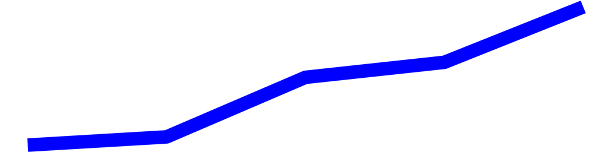

China

17.09

18.21

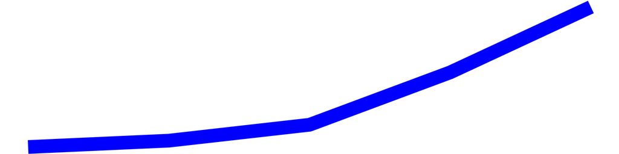

Denmark

41.57

43.68

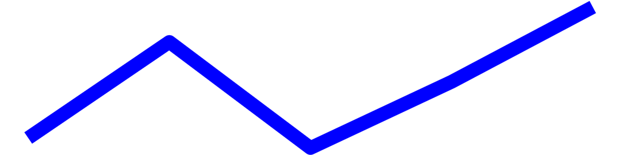

El Salvador

42.60

29.22

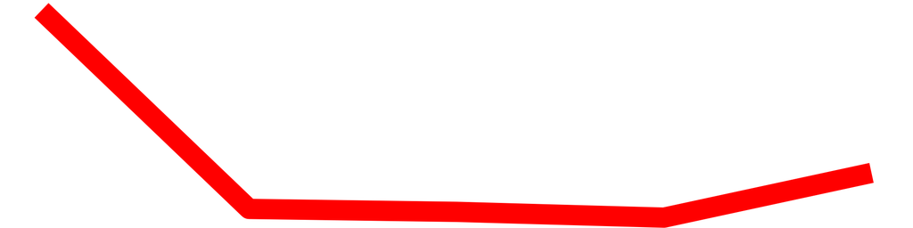

France

43.16

44.05

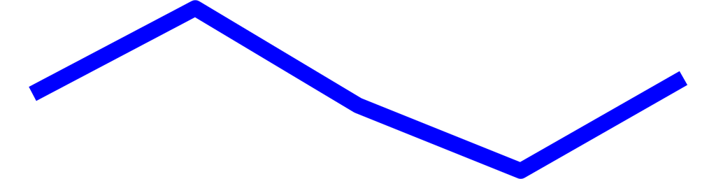

Germany

39.83

46.79

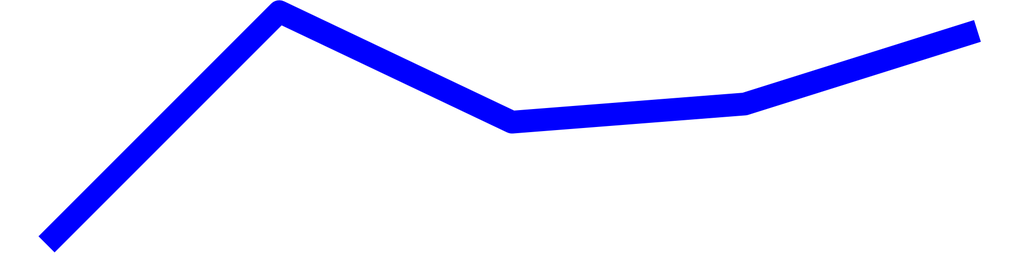

India

22.76

22.31

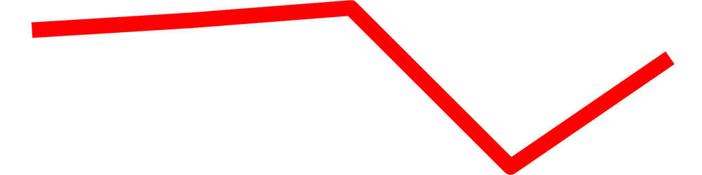

Indonesia

16.02

15.40

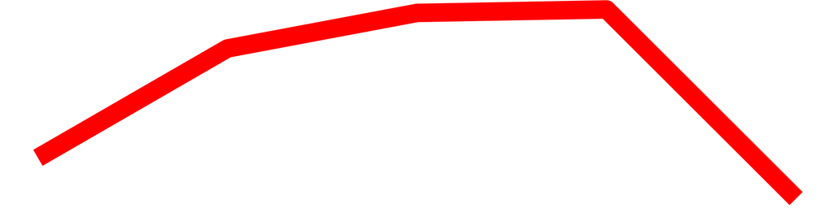

Ireland

38.33

44.83

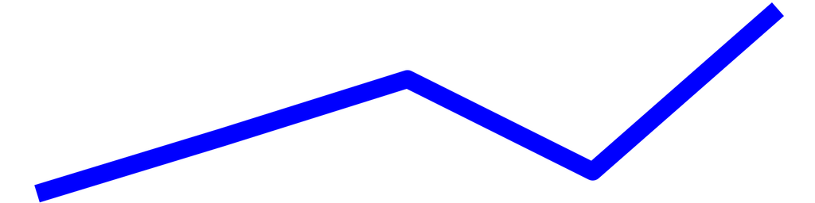

Italy

25.25

27.73

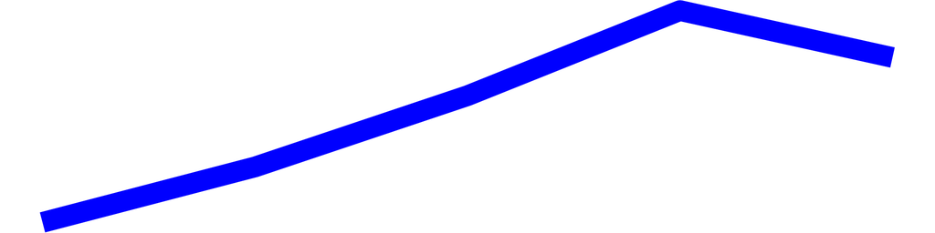

Lebanon

26.08

25.14

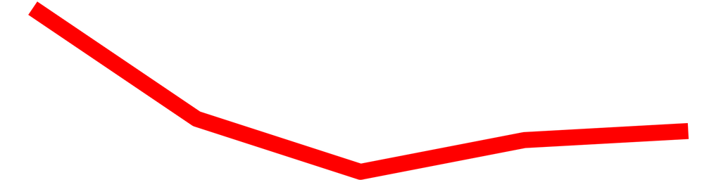

Mexico

26.78

28.95

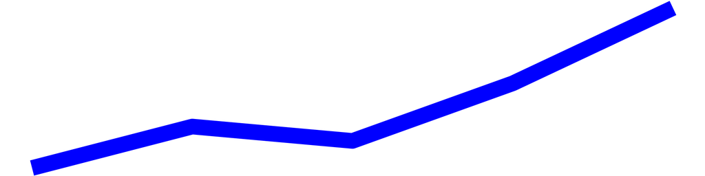

Netherlands

42.21

45.97

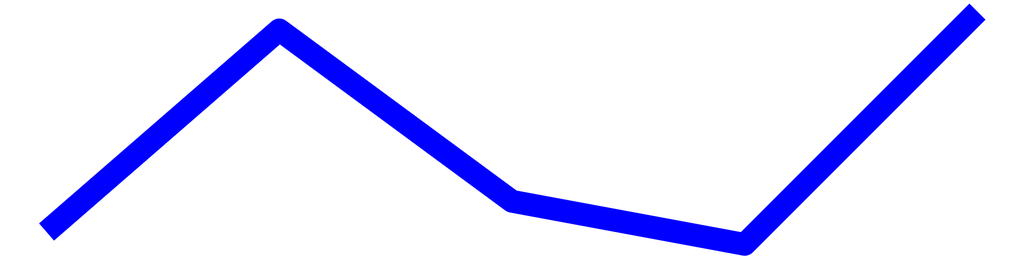

Pakistan

21.81

21.45

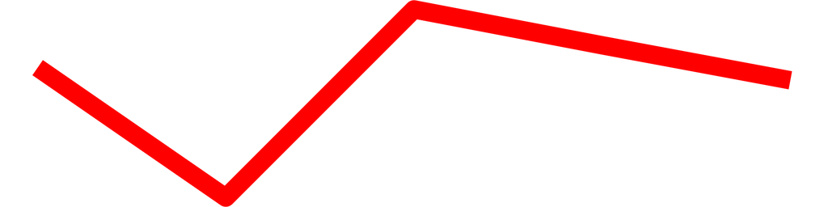

United States

46.36

48.39

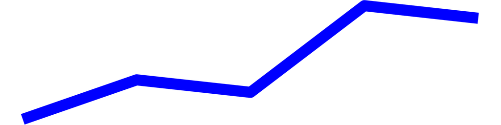

**Table**: @thomas_mock | **Data**: OurWorldInData.org  
**Inspiration**: @jschwabish

### 10. Barplot

For this example we can use barplots to indicate the average across the 5 years. Note that rather than building a ggplot for each of the rows, we can take some influence from the *formattable* R package and create a bar with just HTML/CSS!

There’s quite a bit of code below, but note that the gt package requires you to **parse the HTML with gt::html()**. Overall this method is “cleaner” than via ggplot as you are mutating columns within the same dataset, and it’s much faster since you are just parsing HTML rather than creating, saving, and importing several ggplot images.

Many thanks to the formattable author Renkun Kun and others like rtjohnson12 who have shown examples about how to build up a bar chart with HTML! Thanks also to Christophe Dervieux for a great example of gt + custom HTML on RStudio Community.

| Country | 2013<sup>1</sup> | 2017<sup>1</sup> | Average 2013-17<sup>1</sup> |  |
| --- | --- | --- | --- | --- |
| Brazil | 27.75 | 30.94 | 29.12 |  |
| China | 17.09 | 18.21 | 17.48 |  |
| Denmark | 41.57 | 43.68 | 42.45 |  |
| El Salvador | 42.60 | 29.22 | 29.92 |  |
| France | 43.16 | 44.05 | 43.30 |  |
| Germany | 39.83 | 46.79 | 44.45 |  |
| India | 22.76 | 22.31 | 22.32 |  |
| Indonesia | 16.02 | 15.40 | 17.11 |  |
| Ireland | 38.33 | 44.83 | 40.99 |  |
| Italy | 25.25 | 27.73 | 26.93 |  |
| Lebanon | 26.08 | 25.14 | 25.27 |  |
| Mexico | 26.78 | 28.95 | 27.63 |  |
| Netherlands | 42.21 | 45.97 | 43.71 |  |
| Pakistan | 21.81 | 21.45 | 21.46 |  |
| United States | 46.36 | 48.39 | 47.49 |  |

**Table**: @thomas_mock | **Data**: OurWorldInData.org **Inspiration**: @jschwabish  
<sup>1</sup> Potato Yield in Tonnes per Hectare

### 10. Heatmap

Lastly, you can add colors across the entire plot itself to show trends across the data over time and across country.

**Rule 10 | Heatmap example gt code**

| Country | Potato Yield in Tonnes/Hectare 2013 | Potato Yield in Tonnes/Hectare 2014 | Potato Yield in Tonnes/Hectare 2015 | Potato Yield in Tonnes/Hectare 2016 | Potato Yield in Tonnes/Hectare 2017 |
| --- | --- | --- | --- | --- | --- |
| United States | 46.36 | 47.15 | 46.90 | 48.64 | 48.39 |
| France | 43.16 | 47.98 | 42.51 | 38.83 | 44.05 |
| El Salvador | 42.60 | 26.25 | 26.01 | 25.54 | 29.22 |
| Netherlands | 42.21 | 45.66 | 42.73 | 42.00 | 45.97 |
| Denmark | 41.57 | 43.12 | 41.41 | 42.48 | 43.68 |
| Germany | 39.83 | 47.42 | 43.81 | 44.40 | 46.79 |
| Ireland | 38.33 | 40.32 | 42.36 | 39.11 | 44.83 |
| Brazil | 27.75 | 27.94 | 29.32 | 29.66 | 30.94 |
| Mexico | 26.78 | 27.34 | 27.14 | 27.93 | 28.95 |
| Lebanon | 26.08 | 25.23 | 24.82 | 25.07 | 25.14 |
| Italy | 25.25 | 26.08 | 27.16 | 28.44 | 27.73 |
| India | 22.76 | 22.92 | 23.13 | 20.51 | 22.31 |
| Pakistan | 21.81 | 18.15 | 23.44 | 22.43 | 21.45 |
| China | 17.09 | 17.14 | 17.27 | 17.69 | 18.21 |
| Indonesia | 16.02 | 17.67 | 18.20 | 18.25 | 15.40 |

**Table**: @thomas_mock | **Data**: OurWorldInData.org **Inspiration**: @jschwabish

### 10. Percent Change

Ok I lied! One more example, with color for a numeric column.

**Rule 10 | Percent change example gt code**

| Country | Potato Yield in Tonnes/Hectare 2013 | Potato Yield in Tonnes/Hectare 2014 | Potato Yield in Tonnes/Hectare 2015 | Potato Yield in Tonnes/Hectare 2016 | Potato Yield in Tonnes/Hectare 2017 | Percent Change |  |
| --- | --- | --- | --- | --- | --- | --- | --- |
| Brazil | 27.75 | 27.94 | 29.32 | 29.66 | 30.94 |  | 11.49 |
| China | 17.09 | 17.14 | 17.27 | 17.69 | 18.21 | 6.54 |  |
| Denmark | 41.57 | 43.12 | 41.41 | 42.48 | 43.68 | 5.07 |  |
| El Salvador | 42.60 | 26.25 | 26.01 | 25.54 | 29.22 | −31.41 |  |
| France | 43.16 | 47.98 | 42.51 | 38.83 | 44.05 | 2.06 |  |
| Germany | 39.83 | 47.42 | 43.81 | 44.40 | 46.79 | 17.48 |  |
| India | 22.76 | 22.92 | 23.13 | 20.51 | 22.31 | −2.00 |  |
| Indonesia | 16.02 | 17.67 | 18.20 | 18.25 | 15.40 | −3.83 |  |
| Ireland | 38.33 | 40.32 | 42.36 | 39.11 | 44.83 | 16.96 |  |
| Italy | 25.25 | 26.08 | 27.16 | 28.44 | 27.73 | 9.83 |  |
| Lebanon | 26.08 | 25.23 | 24.82 | 25.07 | 25.14 | −3.60 |  |
| Mexico | 26.78 | 27.34 | 27.14 | 27.93 | 28.95 | 8.12 |  |
| Netherlands | 42.21 | 45.66 | 42.73 | 42.00 | 45.97 | 8.92 |  |
| Pakistan | 21.81 | 18.15 | 23.44 | 22.43 | 21.45 | −1.63 |  |
| United States | 46.36 | 47.15 | 46.90 | 48.64 | 48.39 | 4.38 |  |

**Table**: @thomas_mock | **Data**: OurWorldInData.org **Inspiration**: @jschwabish

### Rule 11: Add Context to the Table

I’ll add one more guideline of my own! We’ve been playing fairly fast and loose with not naming many of the tables and not providing all the context about even what’s in the table, mostly because we’re more concerned with showing curated and specific examples. However, naming and adding context to the table is important. This can be accomplished many different ways with gt.

### Add a title

Going back to our first table - let’s tell the reader what the actual data is!

**Potato yields in 6 major countries**

Yield in Tonnes/Hectare

| Country | 2013 | 2014 | 2015 | 2016 |
| --- | --- | --- | --- | --- |
| China | 17.09 | 17.14 | 17.27 | 17.69 |
| India | 22.76 | 22.92 | 23.13 | 20.51 |
| Indonesia | 16.02 | 17.67 | 18.20 | 18.25 |
| Mexico | 26.78 | 27.34 | 27.14 | 27.93 |
| Pakistan | 21.81 | 18.15 | 23.44 | 22.43 |
| United States | 46.36 | 47.15 | 46.90 | 48.64 |

**Table**: @thomas_mock | **Data**: OurWorldInData.org **Inspiration**: @jschwabish

### Add a a Footer

Alternatively, we could also add a footer to column labels to explain the yields.

| Country | 2013<sup>1</sup> | 2014<sup>1</sup> | 2015<sup>1</sup> | 2016 |
| --- | --- | --- | --- | --- |
| China | 17.09 | 17.14 | 17.27 | 17.69 |
| India | 22.76 | 22.92 | 23.13 | 20.51 |
| Indonesia | 16.02 | 17.67 | 18.20 | 18.25 |
| Mexico | 26.78 | 27.34 | 27.14 | 27.93 |
| Pakistan | 21.81 | 18.15 | 23.44 | 22.43 |
| United States | 46.36 | 47.15 | 46.90 | 48.64 |

**Table**: @thomas_mock | **Data**: OurWorldInData.org **Inspiration**: @jschwabish  
<sup>1</sup> Annual Potato Yield in Tonnes/Hectare

### Redo an example

Going a bit further into our rule 10 examples, while we added some nice color - we could further clarify the percent change, was it the sum of changes? Change from specific years? It was just the change from 2013 vs 2017.

| Country | Potato Yield in Tonnes/Hectare 2013 | Potato Yield in Tonnes/Hectare 2014 | Potato Yield in Tonnes/Hectare 2015 | Potato Yield in Tonnes/Hectare 2016 | Potato Yield in Tonnes/Hectare 2017 | Percent Change<sup>1</sup> |  |
| --- | --- | --- | --- | --- | --- | --- | --- |
| Brazil | 27.75 | 27.94 | 29.32 | 29.66 | 30.94 |  | 11.49 |
| China | 17.09 | 17.14 | 17.27 | 17.69 | 18.21 | 6.54 |  |
| Denmark | 41.57 | 43.12 | 41.41 | 42.48 | 43.68 | 5.07 |  |
| El Salvador | 42.60 | 26.25 | 26.01 | 25.54 | 29.22 | −31.41 |  |
| France | 43.16 | 47.98 | 42.51 | 38.83 | 44.05 | 2.06 |  |
| Germany | 39.83 | 47.42 | 43.81 | 44.40 | 46.79 | 17.48 |  |
| India | 22.76 | 22.92 | 23.13 | 20.51 | 22.31 | −2.00 |  |
| Indonesia | 16.02 | 17.67 | 18.20 | 18.25 | 15.40 | −3.83 |  |
| Ireland | 38.33 | 40.32 | 42.36 | 39.11 | 44.83 | 16.96 |  |
| Italy | 25.25 | 26.08 | 27.16 | 28.44 | 27.73 | 9.83 |  |
| Lebanon | 26.08 | 25.23 | 24.82 | 25.07 | 25.14 | −3.60 |  |
| Mexico | 26.78 | 27.34 | 27.14 | 27.93 | 28.95 | 8.12 |  |
| Netherlands | 42.21 | 45.66 | 42.73 | 42.00 | 45.97 | 8.92 |  |
| Pakistan | 21.81 | 18.15 | 23.44 | 22.43 | 21.45 | −1.63 |  |
| United States | 46.36 | 47.15 | 46.90 | 48.64 | 48.39 | 4.38 |  |

**Table**: @thomas_mock | **Data**: OurWorldInData.org **Inspiration**: @jschwabish  
<sup>1</sup> Percent Change: 2013 vs 2017

| Country | code | 2007 | 2008 | 2009 | 2010 | 2011 | avg_07_11<sup>1</sup> | 2012 | 2013 | 2014 | 2015 | 2016 | avg_12_16<sup>2</sup> |
| --- | --- | --- | --- | --- | --- | --- | --- | --- | --- | --- | --- | --- | --- |
| China | CHN | 14.6283 | 15.1820 | 14.4171 | 15.6686 | 16.2826 | 15.1283 | 16.7712 | 17.0910 | 17.1416 | 17.2684 | 17.6866 | 16.7712 |
| India | IND | 16.4101 | 19.2973 | 18.8103 | 19.9299 | 22.7240 | 19.4101 | 21.7530 | 22.7606 | 22.9224 | 23.1257 | 20.5087 | 21.2530 |
| Indonesia | IDN | 16.0919 | 16.6719 | 16.5123 | 15.9445 | 15.9562 | 16.0919 | 16.5820 | 16.0184 | 17.6668 | 18.2027 | 18.2549 | 17.0820 |
| Mexico | MEX | 27.0565 | 27.7258 | 27.7374 | 27.7578 | 26.2734 | 27.0565 | 26.8098 | 26.7752 | 27.3384 | 27.1435 | 27.9260 | 27.3098 |
| Pakistan | PAK | 19.3516 | 16.4550 | 20.2848 | 22.6823 | 21.9196 | 20.3516 | 18.3405 | 21.8059 | 18.1506 | 23.4439 | 22.4346 | 20.3405 |
| United States | USA | 44.4336 | 44.4373 | 46.4446 | 44.9438 | 44.6923 | 44.4336 | 45.7762 | 46.3577 | 47.1507 | 46.9000 | 48.6408 | 46.7762 |

## Footnotes

[^1]: @jschwabish Tweet Aug 3, 2020
[^2]: https://stackoverflow.com/questions/63944953/how-to-conditionally-format-a-cell-in-a-gt-table-based-on-the-value-of-the-cel
[^3]: Not working because the datasource is a table and not a dataframe